# Exercise Activity Prediction

Raphael Gutierrez

May 8, 2021

### Background

Using devices such as Jawbone Up, Nike FuelBand, and Fitbit it is now possible to collect a large amount of data about personal activity relatively inexpensively. These type of devices are part of the quantified self movement - a group of enthusiasts who take measurements about themselves regularly to improve their health, to find patterns in their behavior, or because they are tech geeks. One thing that people regularly do is quantify how much of a particular activity they do, but they rarely quantify how well they do it. In this project, your goal will be to use data from accelerometers on the belt, forearm, arm, and dumbell of 6 participants. They were asked to perform barbell lifts correctly and incorrectly in 5 different ways. More information is available from the website here: http://web.archive.org/web/20161224072740/http:/groupware.les.inf.puc-rio.br/har (see the section on the Weight Lifting Exercise Dataset).

### Data

The training data for this project are available here: https://d396qusza40orc.cloudfront.net/predmachlearn/pml-training.csv

The test data are available here: https://d396qusza40orc.cloudfront.net/predmachlearn/pml-testing.csv

The data for this project come from this source: http://web.archive.org/web/20161224072740/http:/groupware.les.inf.puc-rio.br/har.

## Data Preparation

### Importing Packages

This loads the necessary R packages for this project. Caret for classification training and models, mainly for Decision Tree, randomForest for Random Forest model, ggplot2 for exploratory analysis, and rattle for tree visualization.

### Downloading Data

The training and testing data required for this project are downloaded in this section.

```r
trainingFile <- "pml-training.csv"
testingFile <- "pml-testing.csv"

download.file("http://d396qusza40orc.cloudfront.net/predmachlearn/pml-training.csv", trainingFile)
download.file("http://d396qusza40orc.cloudfront.net/predmachlearn/pml-testing.csv", testingFile)
```

### Data Preprocessing

Preprocessing is used to clean-up the raw data. All N/A and empty values are omitted.

Subsets will be created to remove unnecessary columns that might affect the prediction of the models. These columns are user_name, raw_timestamp_part_1, raw_timestamp_part_2, cvtd_timestamp, new_window, and num_window.

```r
training <- read.csv(trainingFile, na.strings=c("NA","#DIV/0!", ""))
testing <- read.csv(testingFile, na.strings=c("NA", "#DIV/0!", ""))

training <- training[,colSums(is.na(training)) == 0]
testing <- testing[,colSums(is.na(testing)) == 0]

training <- training[,-c(1:7)]
testing <- testing[,-c(1:7)]
```

### Train-Test Split

Because pml-testing.csv will be used to test the accuracy of the models, pml-training.csv will serve as training and testing sets. Because of this, it is separated into 0.70 (70%) training and 0.30 (30%) testing data.

```r
splittedData <- createDataPartition(y=training$classe, p=0.7, list=FALSE)
sTraining <- training[splittedData,]
sTesting <- training[-splittedData,]
```

### Exploratory Analysis

The data is composed of five (5) classifications. The bar plot shows the distribution of uniquely identified data inside the classe column.

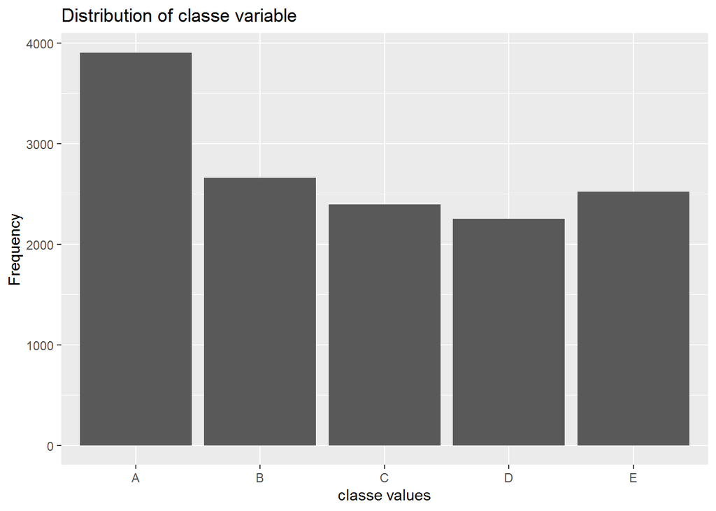

```r
qplot(classe, main="Distribution of classe variable", xlab="classe values", ylab="Frequency", data=sTraining)
```

## Prediction Models

### Decision Tree

Decision Tree algorithm will be used to predict the outcome of the data.

```r
DT_model <- train(classe ~ ., data=sTraining, method="rpart")

DT_model
```

```
## CART
##
## 13737 samples
##    52 predictor
##     5 classes: 'A', 'B', 'C', 'D', 'E'
##
## No pre-processing
## Resampling: Bootstrapped (25 reps)
## Summary of sample sizes: 13737, 13737, 13737, 13737, 13737, 13737, ...
## Resampling results across tuning parameters:
##
##   cp          Accuracy   Kappa
##   0.03529651  0.4964869  0.34225196
##   0.05974299  0.4093501  0.19836304
##   0.11341674  0.3192778  0.05321538
##
## Accuracy was used to select the optimal model using the largest value.
## The final value used for the model was cp = 0.03529651.
```

```r
DT_model$finalModel
```

```
## n= 13737
##
## node), split, n, loss, yval, (yprob)
##       * denotes terminal node
##
##  1) root 13737 9831 A (0.28 0.19 0.17 0.16 0.18)
##    2) roll_belt< 129.5 12532 8671 A (0.31 0.21 0.19 0.18 0.11)
##      4) pitch_forearm< -34.15 1110    6 A (0.99 0.0054 0 0 0) *
##      5) pitch_forearm>=-34.15 11422 8665 A (0.24 0.23 0.21 0.2 0.12)
##       10) magnet_dumbbell_y< 439.5 9640 6943 A (0.28 0.18 0.24 0.19 0.11)
##         20) roll_forearm< 124.5 5974 3571 A (0.4 0.18 0.19 0.17 0.058) *
##         21) roll_forearm>=124.5 3666 2447 C (0.08 0.18 0.33 0.22 0.18) *
##       11) magnet_dumbbell_y>=439.5 1782  885 B (0.034 0.5 0.039 0.23 0.19) *
##    3) roll_belt>=129.5 1205   45 E (0.037 0 0 0 0.96) *
```

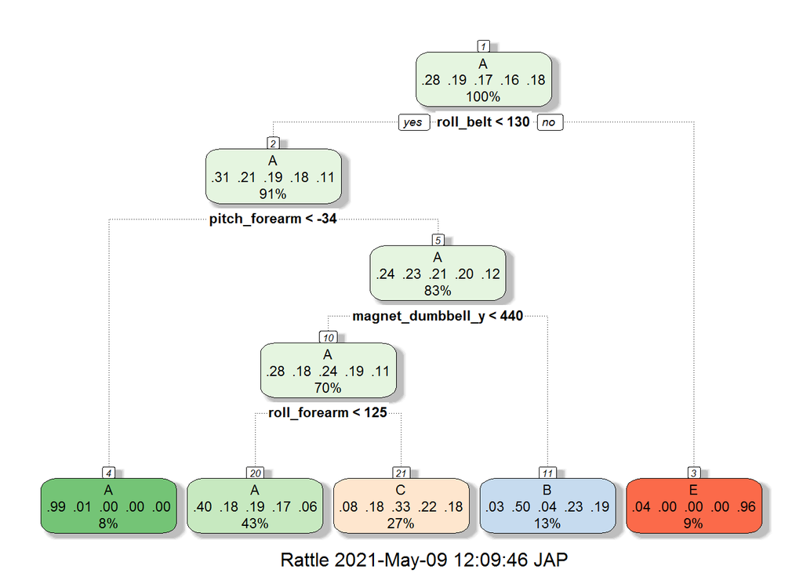

```r
fancyRpartPlot(DT_model$finalModel)
```

```r
pred_DT <- predict(DT_model, newdata=sTesting, typce="class")
```

### Confusion Matrix (Decision Tree)

The following confusion matrix shows the errors and overall statistics of the prediction model.

```r
confusionMatrix(pred_DT, as.factor(sTesting$classe))
```

```
## Confusion Matrix and Statistics
##
##           Reference
## Prediction    A    B    C    D    E
##          A 1514  483  486  441  144
##          B   21  389   38  155  124
##          C  110  267  502  368  275
##          D    0    0    0    0    0
##          E   29    0    0    0  539
##
## Overall Statistics
##
##                Accuracy : 0.5003
##                  95% CI : (0.4874, 0.5131)
##     No Information Rate : 0.2845
##     P-Value [Acc > NIR] : < 2.2e-16
##
##                   Kappa : 0.3467
##
##  Mcnemar's Test P-Value : NA
##
## Statistics by Class:
##
##                      Class: A Class: B Class: C Class: D Class: E
## Sensitivity            0.9044   0.3415   0.4893   0.0000  0.49815
## Specificity            0.6310   0.9288   0.7901   1.0000  0.99396
## Pos Pred Value         0.4935   0.5351   0.3298      NaN  0.94894
## Neg Pred Value         0.9432   0.8546   0.8799   0.8362  0.89787
## Prevalence             0.2845   0.1935   0.1743   0.1638  0.18386
## Detection Rate         0.2573   0.0661   0.0853   0.0000  0.09159
## Detection Prevalence   0.5213   0.1235   0.2586   0.0000  0.09652
## Balanced Accuracy      0.7677   0.6352   0.6397   0.5000  0.74606
```

### Random Forest

Random Forest algorithm will be used to predict the outcome of the data.

```r
RF_model <- randomForest(as.factor(classe) ~ ., data=sTraining, method="class")

RF_model
```

```
##
## Call:
##  randomForest(formula = as.factor(classe) ~ ., data = sTraining,      method = "class")
##                Type of random forest: classification
##                      Number of trees: 500
## No. of variables tried at each split: 7
##
##         OOB estimate of  error rate: 0.55%
## Confusion matrix:
##      A    B    C    D    E  class.error
## A 3903    3    0    0    0 0.0007680492
## B   14 2637    7    0    0 0.0079006772
## C    0   16 2376    4    0 0.0083472454
## D    0    0   22 2229    1 0.0102131439
## E    0    0    2    7 2516 0.0035643564
```

```r
pred_RF <- predict(RF_model, newdata=sTesting, type="class")
```

### Confusion Matrix (Random Forest)

The following confusion matrix shows the errors and overall statistics of the prediction model.

```r
confusionMatrix(pred_RF, as.factor(sTesting$classe))
```

```
## Confusion Matrix and Statistics
##
##           Reference
## Prediction    A    B    C    D    E
##          A 1673    6    0    0    0
##          B    1 1128    8    0    0
##          C    0    5 1014   11    1
##          D    0    0    4  951    4
##          E    0    0    0    2 1077
##
## Overall Statistics
##
##                Accuracy : 0.9929
##                  95% CI : (0.9904, 0.9949)
##     No Information Rate : 0.2845
##     P-Value [Acc > NIR] : < 2.2e-16
##
##                   Kappa : 0.991
##
##  Mcnemar's Test P-Value : NA
##
## Statistics by Class:
##
##                      Class: A Class: B Class: C Class: D Class: E
## Sensitivity            0.9994   0.9903   0.9883   0.9865   0.9954
## Specificity            0.9986   0.9981   0.9965   0.9984   0.9996
## Pos Pred Value         0.9964   0.9921   0.9835   0.9917   0.9981
## Neg Pred Value         0.9998   0.9977   0.9975   0.9974   0.9990
## Prevalence             0.2845   0.1935   0.1743   0.1638   0.1839
## Detection Rate         0.2843   0.1917   0.1723   0.1616   0.1830
## Detection Prevalence   0.2853   0.1932   0.1752   0.1630   0.1833
## Balanced Accuracy      0.9990   0.9942   0.9924   0.9924   0.9975
```

## Conclusion

### Result

The prediction for the pml-testing.csv will be as follows:

```r
prediction <- predict(RF_model, newdata=testing, type="class")

prediction
```

```
##  1  2  3  4  5  6  7  8  9 10 11 12 13 14 15 16 17 18 19 20
##  B  A  B  A  A  E  D  B  A  A  B  C  B  A  E  E  A  B  B  B
## Levels: A B C D E
```

### Out-of-sample Error

Out-of-sample error is a measure of how accurately an algorithm is able to predict outcome values for previously unseen data. This is calculated as 1 - accuracy of the prediction model. Unlike the Decision Tree which produced a not-so-good accuracy for this project, the Random Forest did well with an accuracy of 0.993 which resulted to a minimal out-of-sample error. This means that for every prediction, there is a below 1% chance of the data getting misclassified.